# Assignment 2

## Question 1

1. We’ll read in and display some of the cholesterol measurements of heart attack patients:

```r
my_url <- "http://ritsokiguess.site/STAC32/cholest.csv"
cholest <- read_csv(my_url)
cholest
```

| 2-Day | 4-Day | 14-Day | control |
| --- | --- | --- | --- |
| 270 | 218 | 156 | 196 |
| 236 | 234 | NA | 232 |
| 210 | 214 | 242 | 200 |
| 142 | 116 | NA | 242 |
| 280 | 200 | NA | 206 |
| 272 | 276 | 256 | 178 |
| 160 | 146 | 142 | 184 |
| 220 | 182 | 216 | 198 |
| 226 | 238 | 248 | 160 |
| 242 | 288 | NA | 182 |

[output cut: 20 more lines]

2. We’ll plot the data of the control patients:

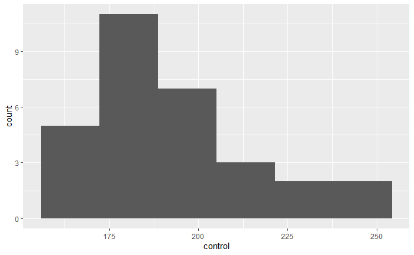

```r
num_bins=nclass.FD(cholest$control)
ggplot(cholest, aes(x = control)) + geom_histogram(bins=num_bins)
```

3. We can see from the graph that the bars representing the number of people are higher on the values that are 200 or below. This means there are more people in the control group that have a cholesterol level in this range compared to the amount of people with a level above 200.

From this we can conclude that the mean of the sample is most likely less than 200.

4. Now we will further infer on what could be possible values of the mean:

```r
t.test(cholest$control)
```

```
    One Sample t-test

data:  cholest$control
t = 47.436, df = 29, p-value < 2.2e-16
alternative hypothesis: true mean is not equal to 0
95 percent confidence interval:
 184.8064 201.4603
sample estimates:
mean of x
 193.1333
```

Based on this output, we are 95% confident that the mean cholesterol level of the control group is between 184 and 201.

## Question 2

1. We’ll read and display some of the data of two groups of students participating in an anchoring experiment:

```r
my_url <- "http://ritsokiguess.site/STAC32/anchoring.csv"
anchoring <- read_csv(my_url)
anchoring
```

| anchor | estimate |
| --- | --- |
| US | 20.0 |
| US | 90.0 |
| US | 1.5 |
| US | 100.0 |
| US | 132.0 |
| US | 150.0 |
| US | 130.0 |
| US | 40.0 |
| US | 200.0 |
| US | 20.0 |

[output cut: 11 more lines]

2. We’ll now plot the data on a suitable plot:

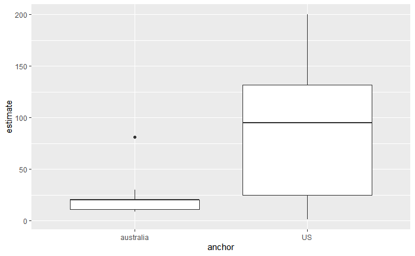

```r
ggplot(anchoring, aes(x=anchor, y=estimate)) + geom_boxplot()
```

3. We want to use the Welch t-test for this sample, the pooled t-test treats the variance of each group as being equal (which we can see is clearly not the case here).
4. We’ll run the t-test and deduce a result:

```r
t.test(estimate~anchor, data=anchoring, alternative="less")
```

```
    Welch Two Sample t-test

data:  estimate by anchor
t = -3.0261, df = 10.558, p-value = 0.006019
alternative hypothesis: true difference in means is less than 0
95 percent confidence interval:
      -Inf -26.63839
sample estimates:
mean in group australia        mean in group US
               22.45455                88.35000
```

5. We can see that the average guess between the two groups has a very large difference between them. The group anchored towards the Australia population had an average guess for the population of Canada being 22.45 million people. On the other sample, the group anchored towards the US population had an average guess of 88.35 million people. Thus we can conclude that the anchoring effect is very much at play in this sample.